# ImageFormation_01d_Diffraction

## Contents

- Diffraction limited optics
- Create a point array scene
- Compute the irradiance
- Diffraction limited optics with f/# = 12
- Print out the 3-parameters
- The psf for the two f/#
- The diffraction-limited blur dependence on wavelength
- Programming note: Notice the data structure returned by oiPlot

## Diffraction limited optics

The spatial resolution of an ideal optical system is limited only by diffraction. We can specify the diffraction in terms of the point spread function of that system. For a circular aperture, we can calculate the diffraction limited point spread function as a function of wavelength. The diffraction-limited point spread function is calculated here and illustrated for various simple cases.

**See also:**

oiCreate, oiCompute, oiSet, oiPlot

```matlab
ieInit
```

## Create a point array scene

Each point will produce an image of the point spread. We make a pretty small scene with many samples so you can visualize the point spread. Zoom the image in the display, and notice the colored fringes!

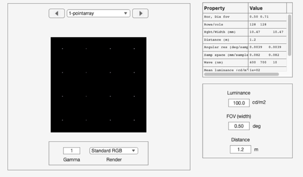

```matlab
sz = 128; spacing = 32;
scene = sceneCreate('point array',sz,spacing);
scene = sceneSet(scene,'h fov',0.5);    % Degrees
sceneWindow(scene);
```

## Compute the irradiance

The default f/# is 4.0. Have a look.

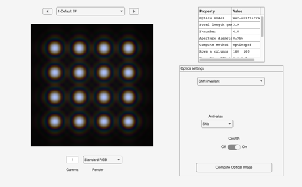

```matlab
oi = oiCreate('wvf');
oi = oiCompute(oi,scene);
oi = oiSet(oi,'name','Default f/#');
oiWindow(oi);
```

## Diffraction limited optics with f/# = 12

The larger f/# blurs the image more, but it has larger depth of field, however, because the aperture is smaller. This is not shown in this picture because all the points are in the same depth plane.

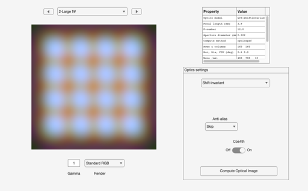

```matlab
oi2 = oiSet(oi,'optics fnumber',12);
oi2 = oiCompute(oi2,scene);
oi2 = oiSet(oi2,'name','Large f/#');
oiWindow(oi2);
```

## Print out the 3-parameters

```matlab
p = oiGet(oi,'optics pupil diameter','mm')
f = oiGet(oi,'optics focal length','mm')
oiGet(oi,'optics f number')
f/p
```

```
p =

    0.9657


f =

    3.8628


ans =

    4.0000


ans =

    4.0000
```

## The psf for the two f/#

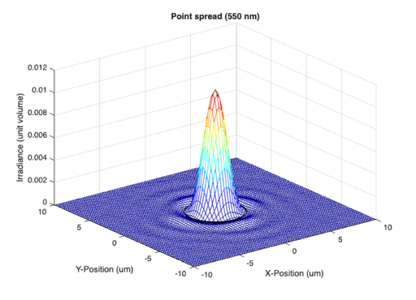

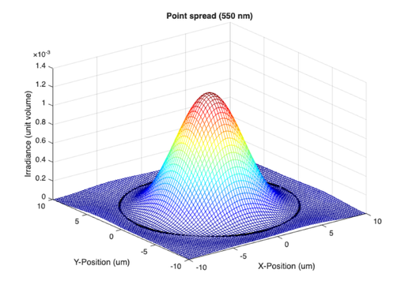

```matlab
oiPlot(oi,'psf 550'); set(gca,'xlim',[-10 10],'ylim',[-10 10])
oiPlot(oi2,'psf 550');set(gca,'xlim',[-10 10],'ylim',[-10 10])
```

## The diffraction-limited blur dependence on wavelength

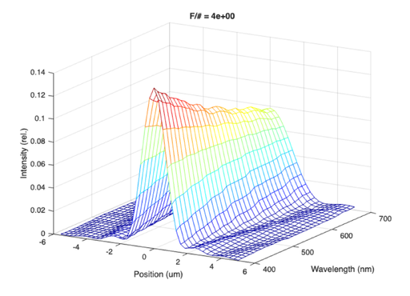

```matlab
ieNewGraphWin;
uData = oiPlot(oi,'ls wavelength');
title(sprintf('F/# = %.0d',oiGet(oi,'optics f number')))
```

## Programming note: Notice the data structure returned by oiPlot

```matlab
uData
```

```
uData =

  struct with fields:

             x: [-5.5484 -5.2842 -5.0200 -4.7558 -4.4916 … ] (1×41 double)
    wavelength: [31×1 single]
        lsWave: [31×41 double]
```

[Published with MATLAB® R2025b](https://www.mathworks.com/products/matlab/)